# NBA Usage Rate & True Shooting %: Predicting 2019-2020 PER

MATT_PEREZ

8/5/2019

## Data Pull

I am huge basketball and NBA fan. I started going to Georgia Tech last year so I wanted to develop a model that will predict an advanced metric for NBA Basketball. I decided to see if I can used 2018-2019 Regular Season data so I can predict the PER (Player Efficiency Rating) for the 2019-2020 season. I pulled the 2018-2019 data from ESPN’s Hollingers Statistics: http://insider.espn.com/nba/hollinger/statistics.

I then uploaded the data sheet into R.

```r
getwd()
```

```
## [1] "/Users/matt/GTOMSA"
```

```r
setwd("/Users/matt/Downloads/")

PER_NBA_2018_2019 = read.csv("PER_NBA_2018_2019.csv",head=T)

head(PER_NBA_2018_2019)
```

```
##   RK                PLAYER TEAM   PER GP  MPG    TS  AST   TO  USG  ORR  DRR REBR    VA  EWA
## 1  1 Giannis Antetokounmpo  MIL 30.95 72 32.8 0.644 18.9 12.0 32.3  7.3 30.0 19.3 684.4 22.8
## 2  2          James Harden  HOU 30.62 78 36.8 0.616 18.0 11.9 40.8  2.5 17.8 10.0 839.5 28.0
## 3  3         Anthony Davis   NO 30.32 56 33.0 0.597 14.1  7.2 29.4  9.9 27.5 18.8 519.7 17.3
## 4  4    Karl-Anthony Towns  MIN 26.38 77 33.1 0.622 12.9 11.9 28.8 10.9 29.3 20.0 599.6 20.0
## 5  5          Nikola Jokic  DEN 26.38 80 31.3 0.589 26.5 11.3 29.4  9.8 27.6 18.7 589.7 19.7
## 6  6           Joel Embiid  PHI 26.21 64 33.7 0.593 12.0 11.6 32.7  8.1 34.0 21.4 501.8 16.7
```

```r
#split the data for testing/training purposes

PER_NBA_2018_2019_ALL =  PER_NBA_2018_2019
head(PER_NBA_2018_2019_ALL)
```

```
##   RK                PLAYER TEAM   PER GP  MPG    TS  AST   TO  USG  ORR  DRR REBR    VA  EWA
## 1  1 Giannis Antetokounmpo  MIL 30.95 72 32.8 0.644 18.9 12.0 32.3  7.3 30.0 19.3 684.4 22.8
## 2  2          James Harden  HOU 30.62 78 36.8 0.616 18.0 11.9 40.8  2.5 17.8 10.0 839.5 28.0
## 3  3         Anthony Davis   NO 30.32 56 33.0 0.597 14.1  7.2 29.4  9.9 27.5 18.8 519.7 17.3
## 4  4    Karl-Anthony Towns  MIN 26.38 77 33.1 0.622 12.9 11.9 28.8 10.9 29.3 20.0 599.6 20.0
## 5  5          Nikola Jokic  DEN 26.38 80 31.3 0.589 26.5 11.3 29.4  9.8 27.6 18.7 589.7 19.7
## 6  6           Joel Embiid  PHI 26.21 64 33.7 0.593 12.0 11.6 32.7  8.1 34.0 21.4 501.8 16.7
```

```r
PER_NBA_2018_2019_NUM = PER_NBA_2018_2019[4:15]

head(PER_NBA_2018_2019_NUM)
```

```
##     PER GP  MPG    TS  AST   TO  USG  ORR  DRR REBR    VA  EWA
## 1 30.95 72 32.8 0.644 18.9 12.0 32.3  7.3 30.0 19.3 684.4 22.8
## 2 30.62 78 36.8 0.616 18.0 11.9 40.8  2.5 17.8 10.0 839.5 28.0
## 3 30.32 56 33.0 0.597 14.1  7.2 29.4  9.9 27.5 18.8 519.7 17.3
## 4 26.38 77 33.1 0.622 12.9 11.9 28.8 10.9 29.3 20.0 599.6 20.0
## 5 26.38 80 31.3 0.589 26.5 11.3 29.4  9.8 27.6 18.7 589.7 19.7
## 6 26.21 64 33.7 0.593 12.0 11.6 32.7  8.1 34.0 21.4 501.8 16.7
```

```r
set.seed(190)
#split the data
NBAtestRows=sample(nrow(PER_NBA_2018_2019_NUM),0.1*nrow(PER_NBA_2018_2019_NUM))
NBAtestData=PER_NBA_2018_2019_NUM[NBAtestRows, ]
NBAtrainData=PER_NBA_2018_2019_NUM[-NBAtestRows, ]


ALLNBAtestRows=sample(nrow(PER_NBA_2018_2019_ALL),0.1*nrow(PER_NBA_2018_2019_ALL))
ALLNBAtestData=PER_NBA_2018_2019_ALL[ALLNBAtestRows, ]
ALLNBAtrainData=PER_NBA_2018_2019_ALL[-ALLNBAtestRows, ]


#NBAtrainData
```

## Plot

```
##              PER           GP         MPG          TS         AST          TO         USG         ORR          DRR        REBR
## PER   1.00000000  0.243522954  0.45863766  0.63143311 -0.07071409  0.09781472  0.64984985  0.50769910  0.557240422  0.57941986
## GP    0.24352295  1.000000000  0.35607226  0.33251150 -0.05163635 -0.10065858  0.11357261  0.03710774  0.002375888  0.01989122
## MPG   0.45863766  0.356072259  1.00000000  0.17484570  0.09467512 -0.04902594  0.54147372 -0.14482458  0.018698872 -0.04325682
## TS    0.63143311  0.332511503  0.17484570  1.00000000 -0.24685912  0.06934373  0.04153880  0.46528713  0.400106367  0.45930022
## AST  -0.07071409 -0.051636354  0.09467512 -0.24685912  1.00000000  0.29070298  0.05543073 -0.31028190 -0.283559312 -0.30975533
## TO    0.09781472 -0.100658584 -0.04902594  0.06934373  0.29070298  1.00000000  0.06514527  0.29145327  0.332681025  0.34105451
## USG   0.64984985  0.113572614  0.54147372  0.04153880  0.05543073  0.06514527  1.00000000 -0.09499214  0.103763037  0.03365783
## ORR   0.50769910  0.037107736 -0.14482458  0.46528713 -0.31028190  0.29145327 -0.09499214  1.00000000  0.734402792  0.88752842
## DRR   0.55724042  0.002375888  0.01869887  0.40010637 -0.28355931  0.33268102  0.10376304  0.73440279  1.000000000  0.96383738
## REBR  0.57941986  0.019891220 -0.04325682  0.45930022 -0.30975533  0.34105451  0.03365783  0.88752842  0.963837380  1.00000000
## VA    0.91574683  0.356681405  0.59727460  0.51085055 -0.03052390  0.05055201  0.68225059  0.33156424  0.425379707  0.42130939
## EWA   0.91562577  0.356220095  0.59672295  0.51072883 -0.03030146  0.05098048  0.68194076  0.33183097  0.425837644  0.42171095
##               VA         EWA
## PER   0.91574683  0.91562577
## GP    0.35668140  0.35622010
## MPG   0.59727460  0.59672295
## TS    0.51085055  0.51072883
## AST  -0.03052390 -0.03030146
## TO    0.05055201  0.05098048
## USG   0.68225059  0.68194076
## ORR   0.33156424  0.33183097
## DRR   0.42537971  0.42583764
## REBR  0.42130939  0.42171095
## VA    1.00000000  0.99998369
## EWA   0.99998369  1.00000000
```

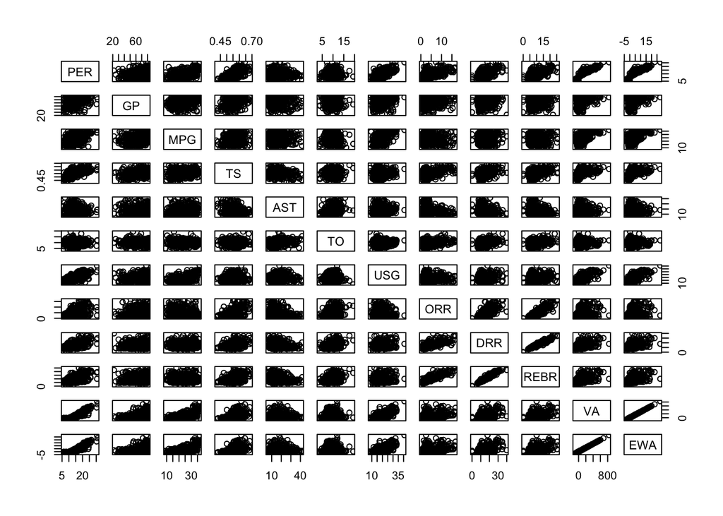

Wins Added and Value Added are highly correlated with Player Efficiency Rating.

I also see that Defensive Rebound Rate is highly correlated with Rebound Rate.

## Create Full Linear Regression Model

```r
set.seed(190)

full_standard_linear_model = lm(PER~ ., data = NBAtrainData)
summary(full_standard_linear_model)
```

```
##
## Call:
## lm(formula = PER ~ ., data = NBAtrainData)
##
## Residuals:
##     Min      1Q  Median      3Q     Max
## -1.8864 -0.5517 -0.0047  0.4655  3.4219
##
## Coefficients:
##               Estimate Std. Error t value Pr(>|t|)
## (Intercept) -11.651318   0.968025 -12.036  < 2e-16 ***
## GP           -0.020700   0.003816  -5.424 1.17e-07 ***
## MPG           0.005466   0.009607   0.569   0.5698
## TS           31.380877   1.393911  22.513  < 2e-16 ***
## AST           0.094718   0.007675  12.341  < 2e-16 ***
## TO           -0.293688   0.025595 -11.475  < 2e-16 ***
## USG           0.364395   0.015406  23.653  < 2e-16 ***
## ORR           0.252888   0.165056   1.532   0.1265
## DRR          -0.047355   0.167301  -0.283   0.7773
## REBR          0.245555   0.333747   0.736   0.4624
## VA            0.098259   0.055798   1.761   0.0792 .
## EWA          -2.614376   1.671559  -1.564   0.1188
## ---
## Signif. codes:  0 '***' 0.001 '**' 0.01 '*' 0.05 '.' 0.1 ' ' 1
##
## Residual standard error: 0.8217 on 313 degrees of freedom
## Multiple R-squared:  0.9707, Adjusted R-squared:  0.9696
## F-statistic: 941.5 on 11 and 313 DF,  p-value: < 2.2e-16
```

## Create Reduced Linear Regression Models

```r
set.seed(190)

reduced_standard_linear_model = lm(PER~ GP+TS+AST+TO+ USG+VA+EWA, data = NBAtrainData)
summary(reduced_standard_linear_model)
```

```
##
## Call:
## lm(formula = PER ~ GP + TS + AST + TO + USG + VA + EWA, data = NBAtrainData)
##
## Residuals:
##     Min      1Q  Median      3Q     Max
## -3.9879 -0.8560 -0.0602  0.7276  4.3841
##
## Coefficients:
##              Estimate Std. Error t value Pr(>|t|)
## (Intercept) -6.681547   1.549668  -4.312 2.17e-05 ***
## GP          -0.041418   0.006200  -6.680 1.07e-10 ***
## TS          32.185825   2.336876  13.773  < 2e-16 ***
## AST          0.003769   0.011324   0.333    0.739
## TO           0.026449   0.037134   0.712    0.477
## USG          0.179966   0.022951   7.841 6.86e-14 ***
## VA           0.148296   0.094471   1.570    0.117
## EWA         -3.840228   2.832005  -1.356    0.176
## ---
## Signif. codes:  0 '***' 0.001 '**' 0.01 '*' 0.05 '.' 0.1 ' ' 1
##
## Residual standard error: 1.405 on 317 degrees of freedom
## Multiple R-squared:  0.9131, Adjusted R-squared:  0.9112
## F-statistic: 475.7 on 7 and 317 DF,  p-value: < 2.2e-16
```

```r
reduced_standard_linear_model_2 = lm(PER~ GP+TS+AST+TO+ USG, data = NBAtrainData)
summary(reduced_standard_linear_model_2)
```

```
##
## Call:
## lm(formula = PER ~ GP + TS + AST + TO + USG, data = NBAtrainData)
##
## Residuals:
##     Min      1Q  Median      3Q     Max
## -5.1049 -1.3313 -0.2045  1.3762  7.7989
##
## Coefficients:
##               Estimate Std. Error t value Pr(>|t|)
## (Intercept) -30.154317   1.577448 -19.116   <2e-16 ***
## GP           -0.011311   0.009104  -1.242    0.215
## TS           61.954657   2.773471  22.338   <2e-16 ***
## AST           0.027945   0.017097   1.635    0.103
## TO           -0.005034   0.056154  -0.090    0.929
## USG           0.544878   0.021855  24.931   <2e-16 ***
## ---
## Signif. codes:  0 '***' 0.001 '**' 0.01 '*' 0.05 '.' 0.1 ' ' 1
##
## Residual standard error: 2.134 on 319 degrees of freedom
## Multiple R-squared:  0.7984, Adjusted R-squared:  0.7952
## F-statistic: 252.7 on 5 and 319 DF,  p-value: < 2.2e-16
```

```r
reduced_standard_linear_model_3 = lm(PER~ TS+USG, data = NBAtrainData)
summary(reduced_standard_linear_model_3)
```

```
##
## Call:
## lm(formula = PER ~ TS + USG, data = NBAtrainData)
##
## Residuals:
##    Min     1Q Median     3Q    Max
## -5.084 -1.468 -0.130  1.354  7.861
##
## Coefficients:
##              Estimate Std. Error t value Pr(>|t|)
## (Intercept) -29.20635    1.43808  -20.31   <2e-16 ***
## TS           59.77933    2.50117   23.90   <2e-16 ***
## USG           0.54346    0.02169   25.05   <2e-16 ***
## ---
## Signif. codes:  0 '***' 0.001 '**' 0.01 '*' 0.05 '.' 0.1 ' ' 1
##
## Residual standard error: 2.138 on 322 degrees of freedom
## Multiple R-squared:  0.7956, Adjusted R-squared:  0.7944
## F-statistic: 626.8 on 2 and 322 DF,  p-value: < 2.2e-16
```